# Trade&Ahead Project

## Context

The stock market has consistently proven to be a good place to invest in and save for the future. There are a lot of compelling reasons to invest in stocks. It can help in fighting inflation, create wealth, and also provides some tax benefits. Good steady returns on investments over a long period of time can also grow a lot more than seems possible. Also, thanks to the power of compound interest, the earlier one starts investing, the larger the corpus one can have for retirement. Overall, investing in stocks can help meet life's financial aspirations.

It is important to maintain a diversified portfolio when investing in stocks in order to maximize earnings under any market condition. Having a diversified portfolio tends to yield higher returns and face lower risk by tempering potential losses when the market is down. It is often easy to get lost in a sea of financial metrics to analyze while determining the worth of a stock, and doing the same for a multitude of stocks to identify the right picks for an individual can be a tedious task. By doing a cluster analysis, one can identify stocks that exhibit similar characteristics and ones that exhibit minimum correlation. This will help investors better analyze stocks across different market segments and help protect against risks that could make the portfolio vulnerable to losses.

## Objective

Trade&Ahead is a financial consultancy firm who provide their customers with personalized investment strategies. They have hired you as a Data Scientist and provided you with data comprising stock price and some financial indicators for a few companies listed under the New York Stock Exchange. They have assigned you the tasks of analyzing the data, grouping the stocks based on the attributes provided, and sharing insights about the characteristics of each group.

## Data Description

The data provided is of stock prices and some financial indicators like ROE, earnings per share, P/E ratio, etc.

## Data Dictionary

- Ticker Symbol: An abbreviation used to uniquely identify publicly traded shares of a particular stock on a particular stock market
- Security: Name of the company
- GICS Sector: The specific economic sector assigned to a company by the Global Industry Classification Standard (GICS) that best defines its business operations
- GICS Sub Industry: The specific sub-industry group assigned to a company by the Global Industry Classification Standard (GICS) that best defines its business operations
- Current Price: Current stock price in dollars
- Price Change: Percentage change in the stock price in 13 weeks
- Volatility: Standard deviation of the stock price over the past 13 weeks
- ROE: A measure of financial performance calculated by dividing net income by shareholders' equity (shareholders' equity is equal to a company's assets minus its debt)
- Cash Ratio: The ratio of a company's total reserves of cash and cash equivalents to its total current liabilities
- Net Cash Flow: The difference between a company's cash inflows and outflows (in dollars)
- Net Income: Revenues minus expenses, interest, and taxes (in dollars)
- Earnings Per Share: Company's net profit divided by the number of common shares it has outstanding (in dollars)
- Estimated Shares Outstanding: Company's stock currently held by all its shareholders
- P/E Ratio: Ratio of the company's current stock price to the earnings per share
- P/B Ratio: Ratio of the company's stock price per share by its book value per share (book value of a company is the net difference between that company's total assets and total liabilities)

### Installing Yellowbricks

```python
pip install -U yellowbrick
```

```
  Attempting uninstall: numpy
    Found existing installation: numpy 1.20.1
    Uninstalling numpy-1.20.1:
      Successfully uninstalled numpy-1.20.1
```

# Importing necessary libraries and data

```python
import pandas as pd
import numpy as np

import matplotlib.pylab as plt
%matplotlib inline

import seaborn as sns
from sklearn.model_selection  import train_test_split
from sklearn.cluster import KMeans
from sklearn.cluster import AgglomerativeClustering
from scipy.cluster.hierarchy import cophenet, dendrogram, linkage
from scipy.spatial.distance import pdist  #Pairwise distribution between data points
from sklearn.decomposition import PCA
from sklearn.preprocessing import StandardScaler
from scipy.spatial.distance import cdist
from scipy.spatial.distance import pdist
from sklearn.metrics import silhouette_score
from yellowbrick.cluster import KElbowVisualizer, SilhouetteVisualizer
from scipy.stats import zscore

import warnings
warnings.filterwarnings('ignore')

# cdist: Compute distance between each pair of the two collections of inputs; XA & XB
# pdist: Pairwise distances between observations in n-dimensional space, one input; X
```

# Load and Review the Data

```python
dfdata = pd.read_csv("stock_data.csv") #import the data
```

```python
dfdata.head() # To check first 5 rows of data set
```

|  | Ticker Symbol | Security | GICS Sector | GICS Sub Industry | Current Price | Price Change | Volatility | ROE | Cash Ratio | Net Cash Flow | Net Income | Earnings Per Share | Estimated Shares Outstanding | P/E Ratio | P/B Ratio |
| --- | --- | --- | --- | --- | --- | --- | --- | --- | --- | --- | --- | --- | --- | --- | --- |
| 0 | AAL | American Airlines Group | Industrials | Airlines | 42.349998 | 9.999995 | 1.687151 | 135 | 51 | -604000000 | 7610000000 | 11.39 | 6.681299e+08 | 3.718174 | -8.784219 |
| 1 | ABBV | AbbVie | Health Care | Pharmaceuticals | 59.240002 | 8.339433 | 2.197887 | 130 | 77 | 51000000 | 5144000000 | 3.15 | 1.633016e+09 | 18.806350 | -8.750068 |
| 2 | ABT | Abbott Laboratories | Health Care | Health Care Equipment | 44.910000 | 11.301121 | 1.273646 | 21 | 67 | 938000000 | 4423000000 | 2.94 | 1.504422e+09 | 15.275510 | -0.394171 |
| 3 | ADBE | Adobe Systems Inc | Information Technology | Application Software | 93.940002 | 13.977195 | 1.357679 | 9 | 180 | -240840000 | 629551000 | 1.26 | 4.996437e+08 | 74.555557 | 4.199651 |
| 4 | ADI | Analog Devices, Inc. | Information Technology | Semiconductors | 55.320000 | -1.827858 | 1.701169 | 14 | 272 | 315120000 | 696878000 | 0.31 | 2.247994e+09 | 178.451613 | 1.059810 |

```python
dfdata.info() # Identify the data types.
```

```
<class 'pandas.core.frame.DataFrame'>
RangeIndex: 340 entries, 0 to 339
Data columns (total 15 columns):
 #   Column                        Non-Null Count  Dtype
---  ------                        --------------  -----
 0   Ticker Symbol                 340 non-null    object
 1   Security                      340 non-null    object
 2   GICS Sector                   340 non-null    object
 3   GICS Sub Industry             340 non-null    object
 4   Current Price                 340 non-null    float64
 5   Price Change                  340 non-null    float64
 6   Volatility                    340 non-null    float64
 7   ROE                           340 non-null    int64
 8   Cash Ratio                    340 non-null    int64
 9   Net Cash Flow                 340 non-null    int64
 10  Net Income                    340 non-null    int64
 11  Earnings Per Share            340 non-null    float64
 12  Estimated Shares Outstanding  340 non-null    float64
 13  P/E Ratio                     340 non-null    float64
 14  P/B Ratio                     340 non-null    float64
dtypes: float64(7), int64(4), object(4)
memory usage: 40.0+ KB
```

```python
dfdata.shape # Check number of columns and rows in data frame
```

```
(340, 15)
```

```python
dfdata.isnull().values.any() # If there are any null values in data set
```

```
False
```

The data does not include any null values.

```python
dfdata.isna().sum()
```

```
Ticker Symbol                   0
Security                        0
GICS Sector                     0
GICS Sub Industry               0
Current Price                   0
Price Change                    0
Volatility                      0
ROE                             0
Cash Ratio                      0
Net Cash Flow                   0
Net Income                      0
Earnings Per Share              0
Estimated Shares Outstanding    0
P/E Ratio                       0
P/B Ratio                       0
dtype: int64
```

The data is not missing any values.

## Identifying Duplicates

```python
dfdata.groupby(dfdata.columns.tolist(),as_index=False).size()
```

|  | Ticker Symbol | Security | GICS Sector | GICS Sub Industry | Current Price | Price Change | Volatility | ROE | Cash Ratio | Net Cash Flow | Net Income | Earnings Per Share | Estimated Shares Outstanding | P/E Ratio | P/B Ratio | size |
| --- | --- | --- | --- | --- | --- | --- | --- | --- | --- | --- | --- | --- | --- | --- | --- | --- |
| 0 | AAL | American Airlines Group | Industrials | Airlines | 42.349998 | 9.999995 | 1.687151 | 135 | 51 | -604000000 | 7610000000 | 11.39 | 6.681299e+08 | 3.718174 | -8.784219 | 1 |
| 1 | ABBV | AbbVie | Health Care | Pharmaceuticals | 59.240002 | 8.339433 | 2.197887 | 130 | 77 | 51000000 | 5144000000 | 3.15 | 1.633016e+09 | 18.806350 | -8.750068 | 1 |
| 2 | ABT | Abbott Laboratories | Health Care | Health Care Equipment | 44.910000 | 11.301121 | 1.273646 | 21 | 67 | 938000000 | 4423000000 | 2.94 | 1.504422e+09 | 15.275510 | -0.394171 | 1 |
| 3 | ADBE | Adobe Systems Inc | Information Technology | Application Software | 93.940002 | 13.977195 | 1.357679 | 9 | 180 | -240840000 | 629551000 | 1.26 | 4.996437e+08 | 74.555557 | 4.199651 | 1 |
| 4 | ADI | Analog Devices, Inc. | Information Technology | Semiconductors | 55.320000 | -1.827858 | 1.701169 | 14 | 272 | 315120000 | 696878000 | 0.31 | 2.247994e+09 | 178.451613 | 1.059810 | 1 |
| ... | ... | ... | ... | ... | ... | ... | ... | ... | ... | ... | ... | ... | ... | ... | ... | ... |
| 335 | YHOO | Yahoo Inc. | Information Technology | Internet Software & Services | 33.259998 | 14.887727 | 1.845149 | 15 | 459 | -1032187000 | -4359082000 | -4.64 | 9.394573e+08 | 28.976191 | 6.261775 | 1 |
| 336 | YUM | Yum! Brands Inc | Consumer Discretionary | Restaurants | 52.516175 | -8.698917 | 1.478877 | 142 | 27 | 159000000 | 1293000000 | 2.97 | 4.353535e+08 | 17.682214 | -3.838260 | 1 |
| 337 | ZBH | Zimmer Biomet Holdings | Health Care | Health Care Equipment | 102.589996 | 9.347683 | 1.404206 | 1 | 100 | 376000000 | 147000000 | 0.78 | 1.884615e+08 | 131.525636 | -23.884449 | 1 |
| 338 | ZION | Zions Bancorp | Financials | Regional Banks | 27.299999 | -1.158588 | 1.468176 | 4 | 99 | -43623000 | 309471000 | 1.20 | 2.578925e+08 | 22.749999 | -0.063096 | 1 |
| 339 | ZTS | Zoetis | Health Care | Pharmaceuticals | 47.919998 | 16.678836 | 1.610285 | 32 | 65 | 272000000 | 339000000 | 0.68 | 4.985294e+08 | 70.470585 | 1.723068 | 1 |

340 rows × 16 columns

The data does not contain duplicates.

```python
dfdata.describe().T # Learn the characteristics of the data.
```

|  | count | mean | std | min | 25% | 50% | 75% | max |
| --- | --- | --- | --- | --- | --- | --- | --- | --- |
| Current Price | 340.0 | 8.086234e+01 | 9.805509e+01 | 4.500000e+00 | 3.855500e+01 | 5.970500e+01 | 9.288000e+01 | 1.274950e+03 |
| Price Change | 340.0 | 4.078194e+00 | 1.200634e+01 | -4.712969e+01 | -9.394838e-01 | 4.819505e+00 | 1.069549e+01 | 5.505168e+01 |
| Volatility | 340.0 | 1.525976e+00 | 5.917984e-01 | 7.331632e-01 | 1.134878e+00 | 1.385593e+00 | 1.695549e+00 | 4.580042e+00 |
| ROE | 340.0 | 3.959706e+01 | 9.654754e+01 | 1.000000e+00 | 9.750000e+00 | 1.500000e+01 | 2.700000e+01 | 9.170000e+02 |
| Cash Ratio | 340.0 | 7.002353e+01 | 9.042133e+01 | 0.000000e+00 | 1.800000e+01 | 4.700000e+01 | 9.900000e+01 | 9.580000e+02 |
| Net Cash Flow | 340.0 | 5.553762e+07 | 1.946365e+09 | -1.120800e+10 | -1.939065e+08 | 2.098000e+06 | 1.698108e+08 | 2.076400e+10 |
| Net Income | 340.0 | 1.494385e+09 | 3.940150e+09 | -2.352800e+10 | 3.523012e+08 | 7.073360e+08 | 1.899000e+09 | 2.444200e+10 |
| Earnings Per Share | 340.0 | 2.776662e+00 | 6.587779e+00 | -6.120000e+01 | 1.557500e+00 | 2.895000e+00 | 4.620000e+00 | 5.009000e+01 |
| Estimated Shares Outstanding | 340.0 | 5.770283e+08 | 8.458496e+08 | 2.767216e+07 | 1.588482e+08 | 3.096751e+08 | 5.731175e+08 | 6.159292e+09 |
| P/E Ratio | 340.0 | 3.261256e+01 | 4.434873e+01 | 2.935451e+00 | 1.504465e+01 | 2.081988e+01 | 3.176476e+01 | 5.280391e+02 |
| P/B Ratio | 340.0 | -1.718249e+00 | 1.396691e+01 | -7.611908e+01 | -4.352056e+00 | -1.067170e+00 | 3.917066e+00 | 1.290646e+02 |

Measures of central tendency do not appear to provide insights. The individual stocks' integer and float values do not appear similar.

```python
# filtering object type columns
cat_columns = dfdata.describe(include=["object"]).columns
cat_columns
```

```
Index(['Ticker Symbol', 'Security', 'GICS Sector', 'GICS Sub Industry'], dtype='object')
```

```python
for i in cat_columns:
    print("Unique values in", i, "are :")
    print(dfdata[i].value_counts())
    print("*" * 50)
```

```
Unique values in Ticker Symbol are :
C       1
SPGI    1
FCX     1
VTR     1
SYF     1
       ..
XRX     1
PM      1
OXY     1
EXPD    1
WHR     1
Name: Ticker Symbol, Length: 340, dtype: int64
Unique values in Security are :
Torchmark Corp.                       1
Union Pacific                         1
The Travelers Companies Inc.          1
Marathon Oil Corp.                    1
United Health Group Inc.              1
                                     ..
Coca Cola Company                     1
Anadarko Petroleum Corp               1
Norfolk Southern Corp.                1
American International Group, Inc.    1
Henry Schein                          1
Name: Security, Length: 340, dtype: int64
Unique values in GICS Sector are :
Industrials                    53
Financials                     49
Consumer Discretionary         40
Health Care                    40
Information Technology         33
Energy                         30
Real Estate                    27
Utilities                      24
Materials                      20
Consumer Staples               19
Telecommunications Services     5
Name: GICS Sector, dtype: int64
Unique values in GICS Sub Industry are :
Oil & Gas Exploration & Production             16
Industrial Conglomerates                       14
REITs                                          14
Electric Utilities                             12
Internet Software & Services                   12
                                               ..
Technology, Hardware, Software and Supplies     1
Distributors                                    1
Technology Hardware, Storage & Peripherals      1
Tires & Rubber                                  1
Home Entertainment Software                     1
Name: GICS Sub Industry, Length: 104, dtype: int64
```

# Data Overview

- The Source Data includes 340 rows and 15 columns.
- The Data types are 7 float, 4 integers, and 4 objects.
  - Float: Current Price, Price Change, Volatility, Earnings Per Share, Estimated Shares Outstanding, P/E Ratio, and P/B Ratio
  - Integer: ROE, Cash Ratio, Net Cash Flow, and Net Income
  - Object: Ticker Symbol, Security, GICS Sector, and GICS Sub Industry
- The Data does not include any missing values.
- The Data does not include any duplicate values.
- The Data is not missing any values.
- The majority of the stocks are classified as Industrials Financials, Consumer Discretionary, Health Care, Information Technology, or Energy.

# Exploratory Data Analysis

# Univariate Analysis

```python
# function to create labeled barplots


def labeled_barplot(data, feature, perc=False, n=None):
    """
    Barplot with percentage at the top

    data: dataframe
    feature: dataframe column
    perc: whether to display percentages instead of count (default is False)
    n: displays the top n category levels (default is None, i.e., display all levels)
    """

    total = len(data[feature])  # length of the column
    count = data[feature].nunique()
    if n is None:
        plt.figure(figsize=(count + 1, 5))
    else:
        plt.figure(figsize=(n + 1, 5))

    plt.xticks(rotation=90, fontsize=15)
    ax = sns.countplot(
        data=data,
        x=feature,
        palette="Paired",
        order=data[feature].value_counts().index[:n].sort_values(),
    )

    for p in ax.patches:
        if perc == True:
            label = "{:.1f}%".format(
                100 * p.get_height() / total
            )  # percentage of each class of the category
        else:
            label = p.get_height()  # count of each level of the category

        x = p.get_x() + p.get_width() / 2  # width of the plot
        y = p.get_height()  # height of the plot

        ax.annotate(
            label,
            (x, y),
            ha="center",
            va="center",
            size=12,
            xytext=(0, 5),
            textcoords="offset points",
        )  # annotate the percentage

    plt.show()  # show the plot
```

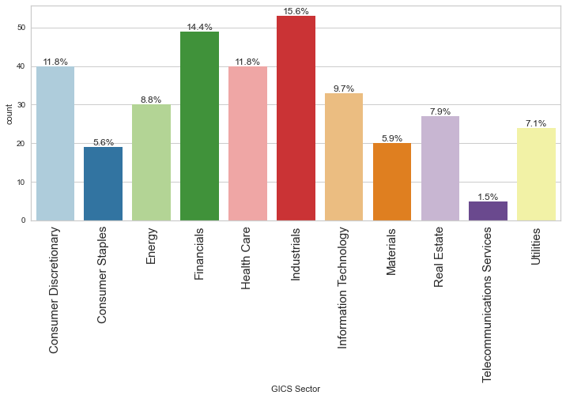

```python
labeled_barplot(dfdata, "GICS Sector", perc=True)
```

#### Observations:

- Industrials account for 15.6%
- Financials account for 14.4%
- Consumer Discretionaries account for 11.8%
- Healthcares account for 11.8%
- Information Technology accounts for 9.7%
- Energy accounts for 8.8%
- Real Estate accounts for 7.9%
- Utilities account for 7.1%
- Materials account for 5.9
- consumer Staples account for 5.6%
- Telecommunication Services account for 1.5%

[figure not shown]

```python
labeled_barplot(dfdata, "GICS Sub Industry", perc=True)
```

```python
# function to plot a boxplot and a histogram along the same scale.


def histogram_boxplot(data, feature, figsize=(12, 7), kde=False, bins=None):
    """
    Boxplot and histogram combined

    data: dataframe
    feature: dataframe column
    figsize: size of figure (default (12,7))
    kde: whether to the show density curve (default False)
    bins: number of bins for histogram (default None)
    """
    f2, (ax_box2, ax_hist2) = plt.subplots(
        nrows=2,  # Number of rows of the subplot grid= 2
        sharex=True,  # x-axis will be shared among all subplots
        gridspec_kw={"height_ratios": (0.25, 0.75)},
        figsize=figsize,
        dpi=100,
    )  # creating the 2 subplots
    sns.boxplot(
        data=data, x=feature, ax=ax_box2, showmeans=True, color="violet"
    )  # boxplot will be created and a star will indicate the mean value of the column
    sns.histplot(
        data=data, x=feature, kde=kde, ax=ax_hist2, bins=bins, palette="winter"
    ) if bins else sns.histplot(
        data=data, x=feature, kde=kde, ax=ax_hist2
    )  # For histogram
    ax_hist2.axvline(
        data[feature].mean(), color="green", linestyle="--"
    )  # Add mean to the histogram
    ax_hist2.axvline(
        data[feature].median(), color="black", linestyle="-"
    )  # Add median to the histogram
```

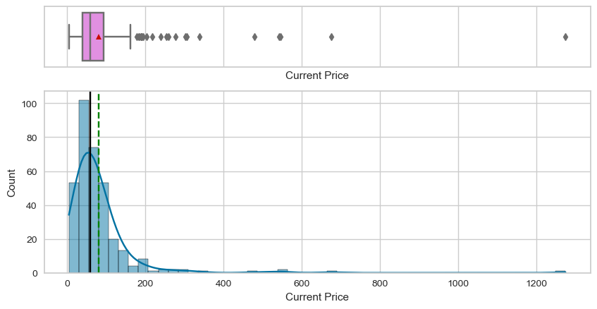

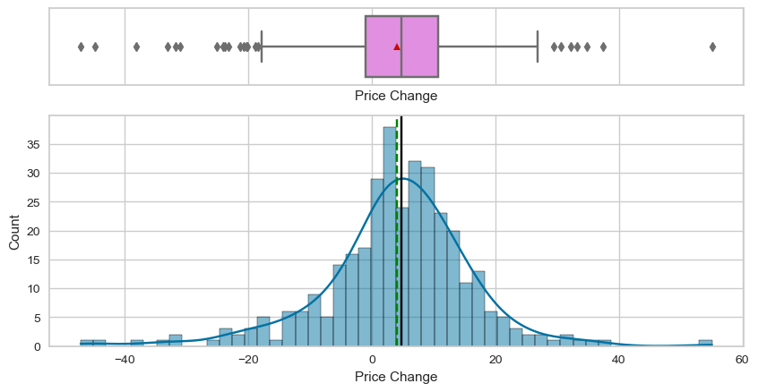

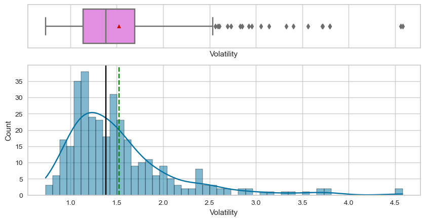

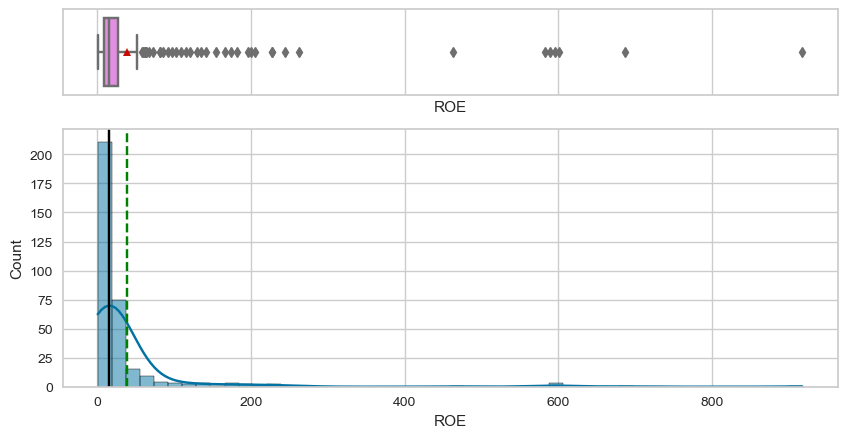

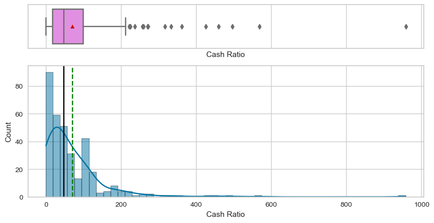

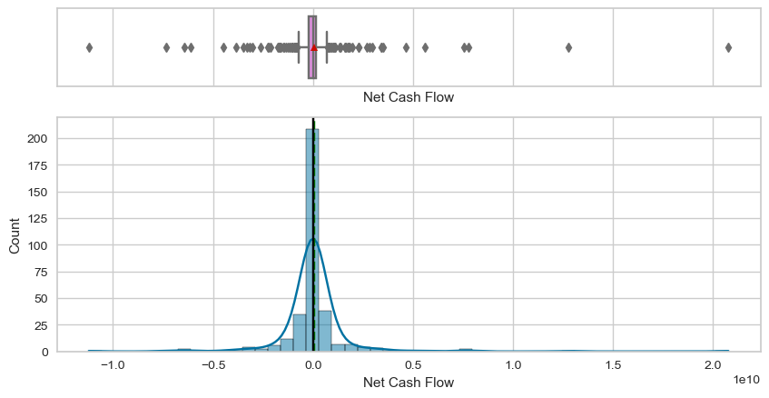

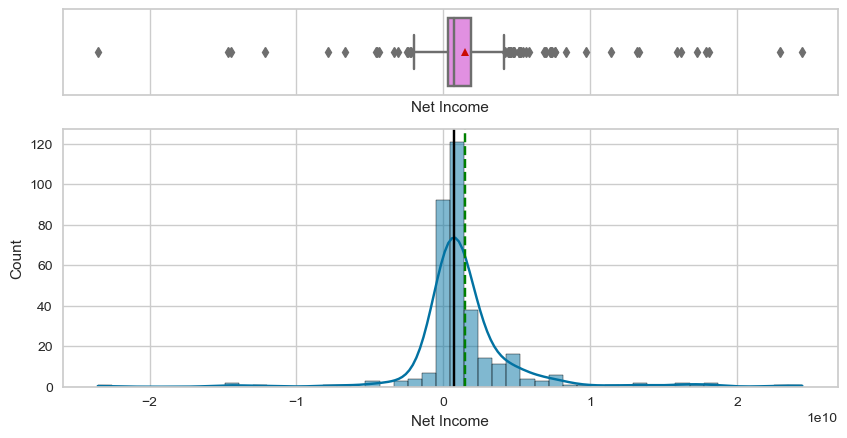

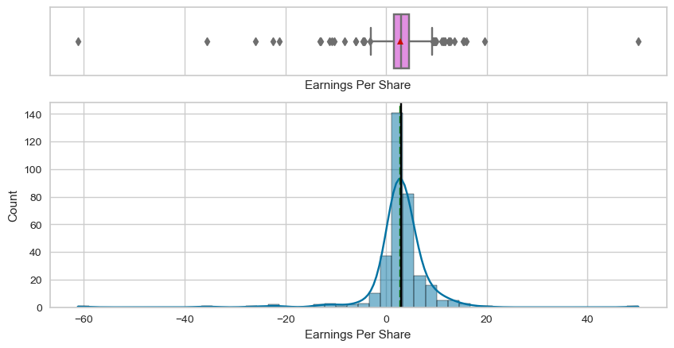

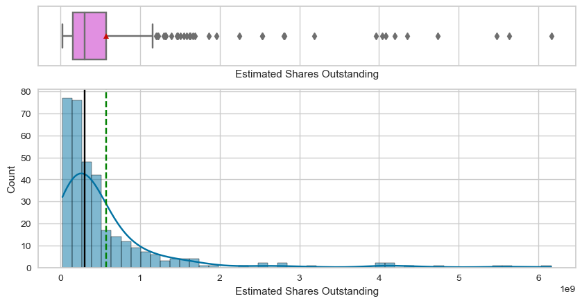

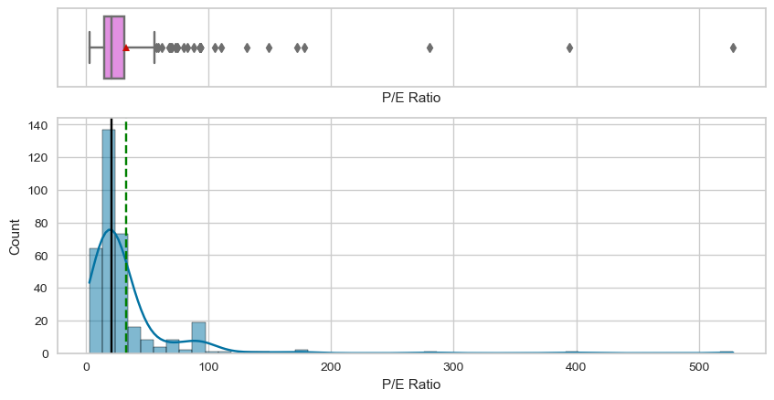

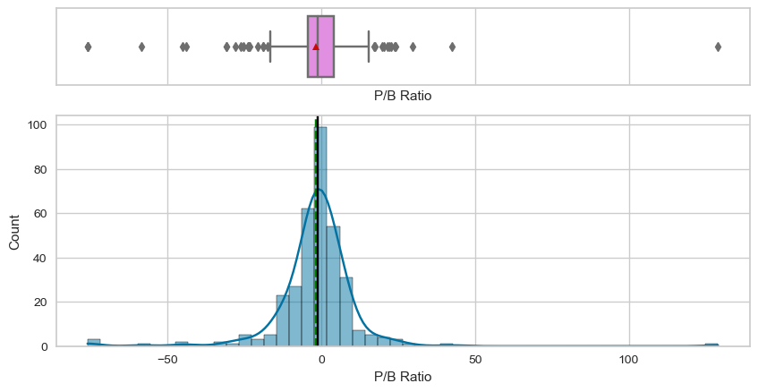

```python
# selecting numerical columns
num_cols = dfdata.select_dtypes(include=np.number).columns.tolist()

for item in num_cols:
    histogram_boxplot(dfdata, item, bins=50, kde=True, figsize=(10, 5))
```

#### Observations:

- Variables like Current Price, Volatility, ROE, Cash Ratio, Estimated Shares Outstanding, and P/E Ratio are right-skewed and have extreme upper outliers.
- Variables like Price Change, Net Cash Flow, Net Income, Earnings Per Share, and P/B Ratio are more normally distributed.
- Outliers exist but will not be treated due to the variables often being key characteristics of certain stocks.

## Bivariate Analysis

### Correlations

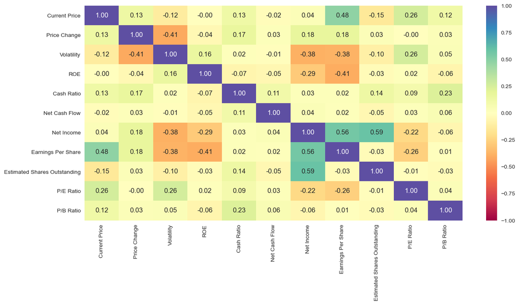

```python
plt.figure(figsize=(15, 7), dpi=100)
sns.heatmap(
    dfdata[num_cols].corr(), annot=True, vmin=-1, vmax=1, fmt=".2f", cmap="Spectral"
)
plt.show()
```

#### Observations:

- Net Income is correlated to Estimated Shares Outstanding and Earnings per Share. It is also somewhat negatively correlated to Volatility and ROE.
- Earnings Per Share is correlated to Current Price and Net Income. It is somewhat negatively correlated to Volatility, ROE, and P/E Ratio.
- P/E Ratio is somewhat correlated to Current Price and Volatility. It is somewhat negatively correlated to Net Income and Earnings Per Share.
- Cash Ratio is somewhat correlated to P/B Ratio.

### Pairplots

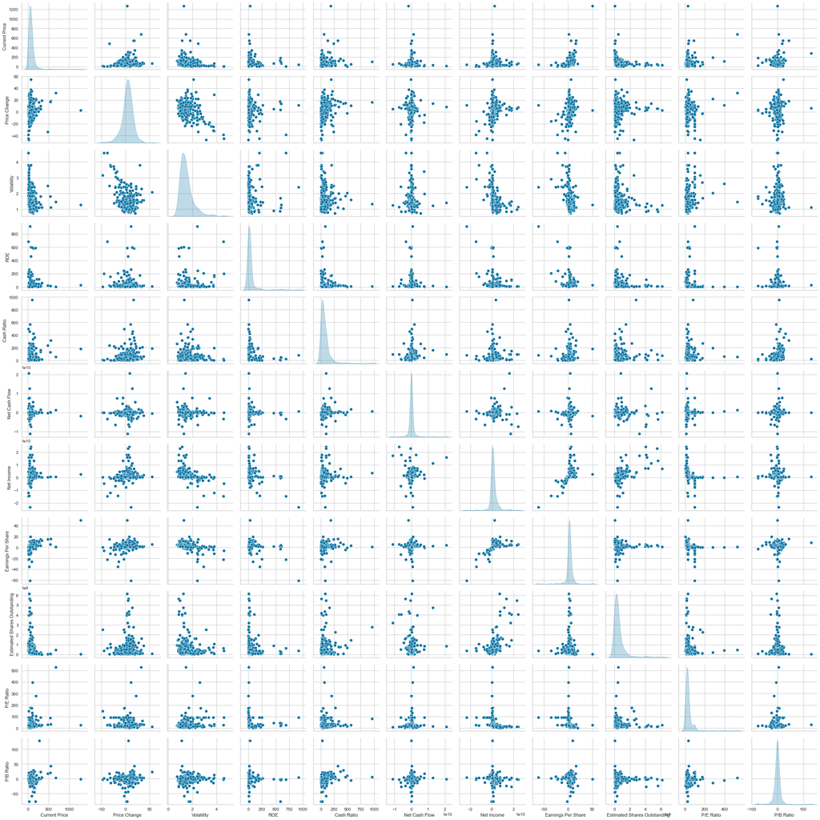

```python
sns.pairplot(dfdata[num_cols],diag_kind="kde");
```

#### Observations:

- Most of the stock bivariate data is concentrated near other stock bivariate data.
- Variables Price Change, Net Cash Flow, Net Income, Earnings Per Share, and P/B Ratio are more normally distributed.

## Scaling the data set before clustering

```python
sc = StandardScaler()
subset_scaled_dfdata = pd.DataFrame(
    sc.fit_transform(dfdata.drop(["Ticker Symbol", "Security", "GICS Sector", "GICS Sub Industry"], axis=1)),
    columns=dfdata.drop(["Ticker Symbol", "Security", "GICS Sector", "GICS Sub Industry"], axis=1).columns,
)
subset_scaled_dfdata.head()
```

|  | Current Price | Price Change | Volatility | ROE | Cash Ratio | Net Cash Flow | Net Income | Earnings Per Share | Estimated Shares Outstanding | P/E Ratio | P/B Ratio |
| --- | --- | --- | --- | --- | --- | --- | --- | --- | --- | --- | --- |
| 0 | -0.393341 | 0.493950 | 0.272749 | 0.989601 | -0.210698 | -0.339355 | 1.554415 | 1.309399 | 0.107863 | -0.652487 | -0.506653 |
| 1 | -0.220837 | 0.355439 | 1.137045 | 0.937737 | 0.077269 | -0.002335 | 0.927628 | 0.056755 | 1.250274 | -0.311769 | -0.504205 |
| 2 | -0.367195 | 0.602479 | -0.427007 | -0.192905 | -0.033488 | 0.454058 | 0.744371 | 0.024831 | 1.098021 | -0.391502 | 0.094941 |
| 3 | 0.133567 | 0.825696 | -0.284802 | -0.317379 | 1.218059 | -0.152497 | -0.219816 | -0.230563 | -0.091622 | 0.947148 | 0.424333 |
| 4 | -0.260874 | -0.492636 | 0.296470 | -0.265515 | 2.237018 | 0.133564 | -0.202703 | -0.374982 | 1.978399 | 3.293307 | 0.199196 |

## 1. Selecting k with the Elbow Method

```
Number of Clusters: 1 	Average Distortion: 2.5425069919221697
Number of Clusters: 2 	Average Distortion: 2.382318498894466
Number of Clusters: 3 	Average Distortion: 2.2692367155390745
Number of Clusters: 4 	Average Distortion: 2.1745559827866363
Number of Clusters: 5 	Average Distortion: 2.128799332840716
Number of Clusters: 6 	Average Distortion: 2.080400099226289
Number of Clusters: 7 	Average Distortion: 2.0289794220177395
Number of Clusters: 8 	Average Distortion: 1.964144163389972
```

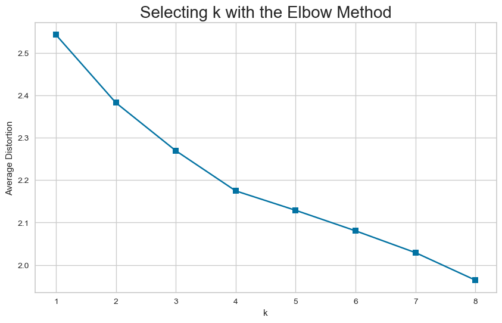

```python
clusters = range(1,9)
meanDistortions = []

for k in clusters:
    model = KMeans(n_clusters=k, random_state=1)
    model.fit(subset_scaled_dfdata)
    prediction = model.predict(subset_scaled_dfdata) # Predict the closest cluster each sample in X belongs to.
    distortion = sum(np.min(cdist(subset_scaled_dfdata, model.cluster_centers_, 'euclidean'), axis=1))/subset_scaled_dfdata.shape[0]

    # distortion: Calculate euclidean(here) distance between each point and each centroid,
    # keep the minimum distances for each point (closest points to a centroid),
    # then calculate the average of minimum distances for each model (or each k)

    meanDistortions.append(distortion)

    print('Number of Clusters:', k, '\tAverage Distortion:', distortion)

plt.figure(figsize=(10,6), dpi=100)
plt.plot(clusters, meanDistortions, '-s')
plt.xlabel('k')
plt.ylabel('Average Distortion')
plt.title('Selecting k with the Elbow Method', fontsize=20);
```

The appropriate value of k from elbow curve seems to be 4 or 5.

## Silhouette Score

```python
sil_score = []
cluster_list = list(range(2,10))

for n_clusters in cluster_list:
    clusterer = KMeans(n_clusters=n_clusters, random_state=1)
    preds = clusterer.fit_predict((subset_scaled_dfdata))
    # centers = clusterer.cluster_centers_
    score = silhouette_score(subset_scaled_dfdata, preds)
    sil_score.append(score)
    print("For n_clusters = {}, silhouette score is {})".format(n_clusters, score))
```

```
For n_clusters = 2, silhouette score is 0.43969639509980457)
For n_clusters = 3, silhouette score is 0.4644405674779404)
For n_clusters = 4, silhouette score is 0.4577225970476733)
For n_clusters = 5, silhouette score is 0.43228336443659804)
For n_clusters = 6, silhouette score is 0.4005422737213617)
For n_clusters = 7, silhouette score is 0.3976335364987305)
For n_clusters = 8, silhouette score is 0.40278401969450467)
For n_clusters = 9, silhouette score is 0.3778585981433699)
```

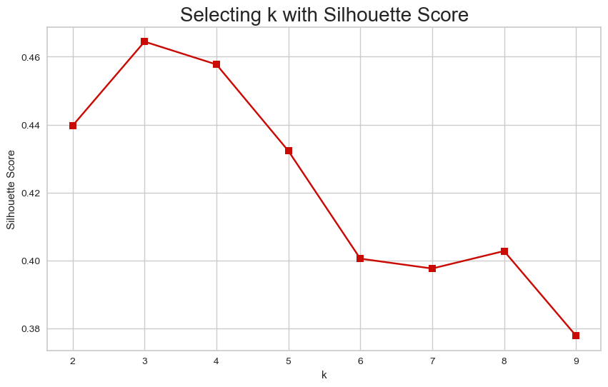

```python
plt.figure(figsize=(10,6), dpi=100)
plt.plot(cluster_list, sil_score, '-rs')
plt.xlabel('k')
plt.ylabel('Silhouette Score')
plt.title('Selecting k with Silhouette Score', fontsize=20);
```

Silhouette score is maximized at k = 3, so it seems 3 is good value of k.

## 2. Finding optimal no. of clusters (K) with silhouette coefficients

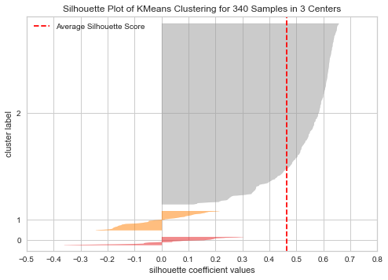

```python
visualizer = SilhouetteVisualizer(KMeans(3, random_state = 1))
visualizer.fit(subset_scaled_dfdata)
visualizer.show()
```

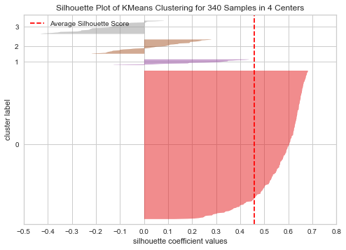

```python
visualizer = SilhouetteVisualizer(KMeans(4, random_state = 1))
visualizer.fit(subset_scaled_dfdata)
visualizer.show()
```

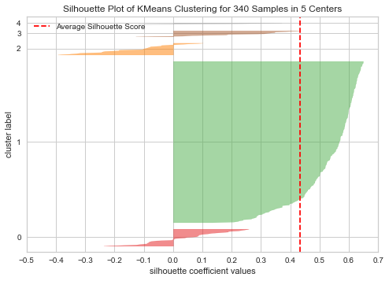

```python
visualizer = SilhouetteVisualizer(KMeans(5, random_state = 1))
visualizer.fit(subset_scaled_dfdata)
visualizer.show()
```

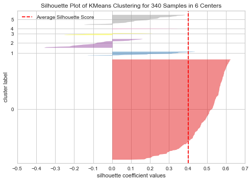

```python
visualizer = SilhouetteVisualizer(KMeans(6, random_state = 1))
visualizer.fit(subset_scaled_dfdata)
visualizer.show()
```

### Let us take k=5 as appropriate no. of clusters as silhoutte score is high enough and there is knick at 5 in elbow curve.

```python
kmeans = KMeans(n_clusters=5, random_state=0)
kmeans.fit(subset_scaled_dfdata)
```

```
KMeans(n_clusters=5, random_state=0)
```

```python
dfdata['K_means_segments'] = kmeans.labels_
```

```python
dfdata.head()
```

|  | Ticker Symbol | Security | GICS Sector | GICS Sub Industry | Current Price | Price Change | Volatility | ROE | Cash Ratio | Net Cash Flow | Net Income | Earnings Per Share | Estimated Shares Outstanding | P/E Ratio | P/B Ratio | K_means_segments |
| --- | --- | --- | --- | --- | --- | --- | --- | --- | --- | --- | --- | --- | --- | --- | --- | --- |
| 0 | AAL | American Airlines Group | Industrials | Airlines | 42.349998 | 9.999995 | 1.687151 | 135 | 51 | -604000000 | 7610000000 | 11.39 | 6.681299e+08 | 3.718174 | -8.784219 | 4 |
| 1 | ABBV | AbbVie | Health Care | Pharmaceuticals | 59.240002 | 8.339433 | 2.197887 | 130 | 77 | 51000000 | 5144000000 | 3.15 | 1.633016e+09 | 18.806350 | -8.750068 | 4 |
| 2 | ABT | Abbott Laboratories | Health Care | Health Care Equipment | 44.910000 | 11.301121 | 1.273646 | 21 | 67 | 938000000 | 4423000000 | 2.94 | 1.504422e+09 | 15.275510 | -0.394171 | 4 |
| 3 | ADBE | Adobe Systems Inc | Information Technology | Application Software | 93.940002 | 13.977195 | 1.357679 | 9 | 180 | -240840000 | 629551000 | 1.26 | 4.996437e+08 | 74.555557 | 4.199651 | 4 |
| 4 | ADI | Analog Devices, Inc. | Information Technology | Semiconductors | 55.320000 | -1.827858 | 1.701169 | 14 | 272 | 315120000 | 696878000 | 0.31 | 2.247994e+09 | 178.451613 | 1.059810 | 0 |

```python
cluster_profile = dfdata.groupby('K_means_segments').mean()
cluster_profile
```

| K_means_segments | Current Price | Price Change | Volatility | ROE | Cash Ratio | Net Cash Flow | Net Income | Earnings Per Share | Estimated Shares Outstanding | P/E Ratio | P/B Ratio |
| --- | --- | --- | --- | --- | --- | --- | --- | --- | --- | --- | --- |
| 0 | 246.574304 | 14.284326 | 1.769621 | 26.500000 | 279.916667 | 4.591202e+08 | 1.009206e+09 | 6.167917 | 5.494321e+08 | 90.097512 | 14.081386 |
| 1 | 41.373681 | -14.849938 | 2.596790 | 27.285714 | 64.457143 | 3.446266e+07 | -1.293864e+09 | -2.459714 | 4.501004e+08 | 61.563930 | 2.476202 |
| 2 | 48.103077 | 6.053507 | 1.163964 | 27.538462 | 77.230769 | 7.732308e+08 | 1.411492e+10 | 3.958462 | 3.918735e+09 | 16.098039 | -4.253404 |
| 3 | 72.783335 | 0.912232 | 2.015435 | 542.666667 | 34.000000 | -3.508667e+08 | -5.843678e+09 | -14.735556 | 3.725000e+08 | 53.574485 | -8.831054 |
| 4 | 72.768128 | 5.701175 | 1.359857 | 25.598456 | 52.216216 | -9.130811e+05 | 1.537661e+09 | 3.719247 | 4.361146e+08 | 23.473934 | -3.374716 |

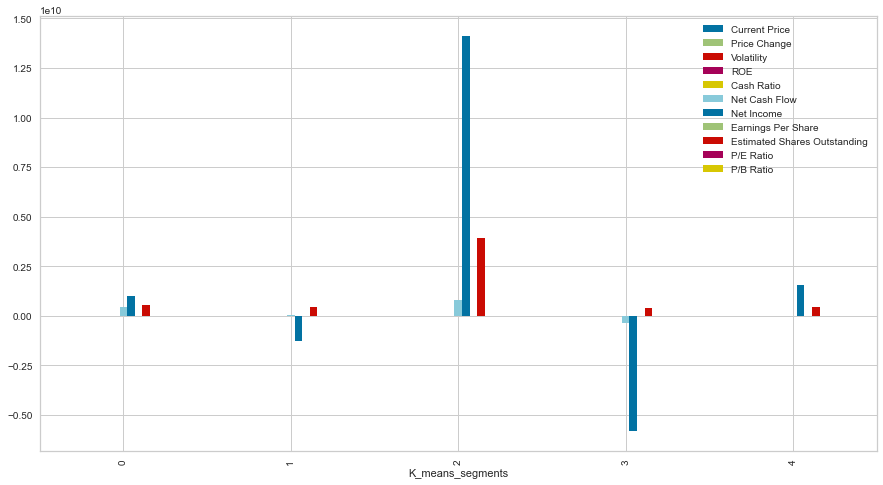

```python
cluster_profile.plot.bar(figsize=(15,8));
```

```python
# cluster_profile['count_in_each_segment'] = df.groupby('K_means_segments')['Fees'].count().values

cluster_profile['count_in_each_segment'] = dfdata.groupby('K_means_segments').size()
cluster_profile
```

| K_means_segments | Current Price | Price Change | Volatility | ROE | Cash Ratio | Net Cash Flow | Net Income | Earnings Per Share | Estimated Shares Outstanding | P/E Ratio | P/B Ratio | count_in_each_segment |
| --- | --- | --- | --- | --- | --- | --- | --- | --- | --- | --- | --- | --- |
| 0 | 246.574304 | 14.284326 | 1.769621 | 26.500000 | 279.916667 | 4.591202e+08 | 1.009206e+09 | 6.167917 | 5.494321e+08 | 90.097512 | 14.081386 | 24 |
| 1 | 41.373681 | -14.849938 | 2.596790 | 27.285714 | 64.457143 | 3.446266e+07 | -1.293864e+09 | -2.459714 | 4.501004e+08 | 61.563930 | 2.476202 | 35 |
| 2 | 48.103077 | 6.053507 | 1.163964 | 27.538462 | 77.230769 | 7.732308e+08 | 1.411492e+10 | 3.958462 | 3.918735e+09 | 16.098039 | -4.253404 | 13 |
| 3 | 72.783335 | 0.912232 | 2.015435 | 542.666667 | 34.000000 | -3.508667e+08 | -5.843678e+09 | -14.735556 | 3.725000e+08 | 53.574485 | -8.831054 | 9 |
| 4 | 72.768128 | 5.701175 | 1.359857 | 25.598456 | 52.216216 | -9.130811e+05 | 1.537661e+09 | 3.719247 | 4.361146e+08 | 23.473934 | -3.374716 | 259 |

Cluster 0 includes 24 securities, Cluster 1 includes 35 securities, Cluster 2 includes 13 securities, Cluster 3 includes 9 securities, and Cluster 4 includes 259 securities. This is sufficient variety to draw insights.

```python
# fig, axes = plt.subplots(1, 5,  figsize=(16, 6))
# fig.suptitle('Boxplot of numerical variables for each cluster')
# counter = 0
# for ii in range(5):
#     sns.boxplot(ax=axes[ii],y=dfdata[all_col[counter]],x=dfdata['K_means_segments'])
#     counter = counter+1

# fig.tight_layout(pad=2.0)
```

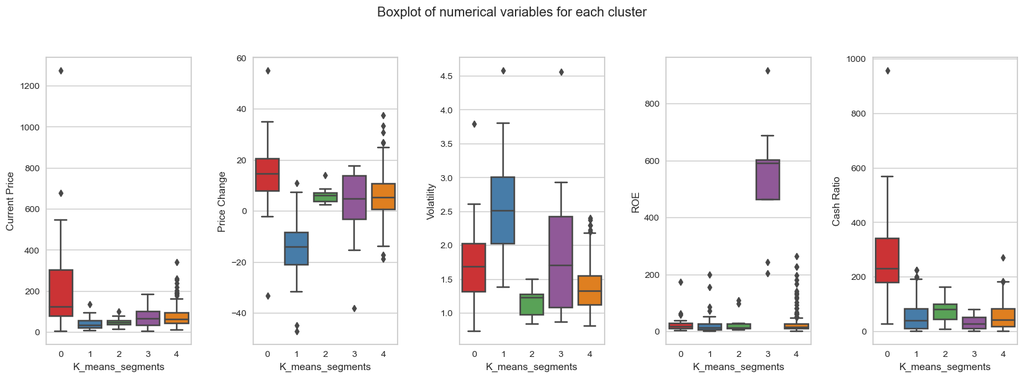

```python
fig, axes = plt.subplots(1, 5,  figsize=(16, 6), dpi=100)
fig.suptitle('Boxplot of numerical variables for each cluster')

for ii in range(5):
    sns.boxplot(ax=axes[ii], y=dfdata[num_cols[ii]], x=dfdata['K_means_segments'], palette='Set1')

fig.tight_layout(pad=2.0)
```

# Hierarchical Clustering

```python
# list of distance metrics
distance_metrics = ["euclidean", "chebyshev", "mahalanobis", "cityblock"]

# list of linkage methods: Distance between clusters
linkage_methods = ["single", "complete", "average", "weighted"]

high_cophenet_corr = 0
high_dm_lm = [0, 0]  # [dm,lm]

for dm in distance_metrics:
    for lm in linkage_methods:
        Z = linkage(subset_scaled_dfdata, metric=dm, method=lm)
        # Z: The hierarchical clustering encoded as a linkage matrix (or as an array).
        c, coph_dists = cophenet(Z, pdist(subset_scaled_dfdata))
        print(
            "Cophenetic correlation for {} distance and {} linkage is {}.".format(
                dm.capitalize(), lm, c
            )
        )
        if high_cophenet_corr < c:
            high_cophenet_corr = c
            high_dm_lm[0] = dm
            high_dm_lm[1] = lm
```

```
Cophenetic correlation for Euclidean distance and single linkage is 0.9232271494002922.
Cophenetic correlation for Euclidean distance and complete linkage is 0.7873280186580672.
Cophenetic correlation for Euclidean distance and average linkage is 0.9422540609560814.
Cophenetic correlation for Euclidean distance and weighted linkage is 0.8693784298129404.
Cophenetic correlation for Chebyshev distance and single linkage is 0.9062538164750717.
Cophenetic correlation for Chebyshev distance and complete linkage is 0.598891419111242.
Cophenetic correlation for Chebyshev distance and average linkage is 0.9338265528030499.
Cophenetic correlation for Chebyshev distance and weighted linkage is 0.9127355892367.
Cophenetic correlation for Mahalanobis distance and single linkage is 0.9259195530524589.
Cophenetic correlation for Mahalanobis distance and complete linkage is 0.7925307202850003.
Cophenetic correlation for Mahalanobis distance and average linkage is 0.9247324030159737.
Cophenetic correlation for Mahalanobis distance and weighted linkage is 0.8708317490180426.
Cophenetic correlation for Cityblock distance and single linkage is 0.9334186366528574.
Cophenetic correlation for Cityblock distance and complete linkage is 0.7375328863205818.
Cophenetic correlation for Cityblock distance and average linkage is 0.9302145048594667.
Cophenetic correlation for Cityblock distance and weighted linkage is 0.731045513520281.
```

```python
# printing the combination of distance metric and linkage method with the highest cophenetic correlation
print(
    "Highest cophenetic correlation is {}, which is obtained with {} distance and {} linkage.".format(
        high_cophenet_corr, high_dm_lm[0].capitalize(), high_dm_lm[1]
    )
)
```

```
Highest cophenetic correlation is 0.9422540609560814, which is obtained with Euclidean distance and average linkage.
```

#### Exploring different linkage methods with Euclidean distance only.

```python
# list of linkage methods
linkage_methods = ["single", "complete", "average", "centroid", "ward", "weighted"]

high_cophenet_corr = 0
high_dm_lm = [0, 0]

for lm in linkage_methods:
    Z = linkage(subset_scaled_dfdata, metric="euclidean", method=lm)
    c, coph_dists = cophenet(Z, pdist(subset_scaled_dfdata))
    print("Cophenetic correlation for {} linkage is {}.".format(lm, c))
    if high_cophenet_corr < c:
        high_cophenet_corr = c
        high_dm_lm[0] = "euclidean"
        high_dm_lm[1] = lm
```

```
Cophenetic correlation for single linkage is 0.9232271494002922.
Cophenetic correlation for complete linkage is 0.7873280186580672.
Cophenetic correlation for average linkage is 0.9422540609560814.
Cophenetic correlation for centroid linkage is 0.9314012446828154.
Cophenetic correlation for ward linkage is 0.7101180299865353.
Cophenetic correlation for weighted linkage is 0.8693784298129404.
```

```python
# printing the combination of distance metric and linkage method with the highest cophenetic correlation
print(
    "Highest cophenetic correlation is {}, which is obtained with {} linkage.".format(
        high_cophenet_corr, high_dm_lm[1]
    )
)
```

```
Highest cophenetic correlation is 0.9422540609560814, which is obtained with average linkage.
```

#### The highest Cophenetic correlation is obtained with Euclidean distance and average linkage.

#### Viewing the dendrograms for the different linkage methods.

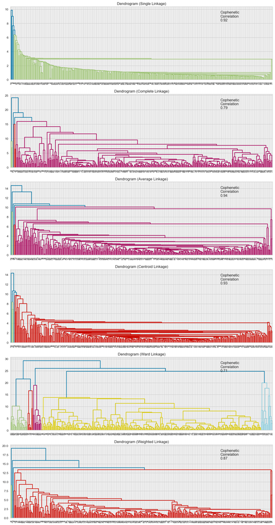

```python
# list of linkage methods
linkage_methods = ["single", "complete", "average", "centroid", "ward", "weighted"]

# lists to save results of cophenetic correlation calculation
compare_cols = ["Linkage", "Cophenetic Coefficient"]

# to create a subplot image
fig, axs = plt.subplots(len(linkage_methods), 1, figsize=(15, 30), dpi=100)

# We will enumerate through the list of linkage methods above
# For each linkage method, we will plot the dendrogram and calculate the cophenetic correlation

for i, method in enumerate(linkage_methods):
    Z = linkage(subset_scaled_dfdata, metric="euclidean", method=method)

    dendrogram(Z, ax=axs[i])
    axs[i].set_title(f"Dendrogram ({method.capitalize()} Linkage)")

    coph_corr, coph_dist = cophenet(Z, pdist(subset_scaled_dfdata))
    axs[i].annotate(
        f"Cophenetic\nCorrelation\n{coph_corr:0.2f}",
        (0.80, 0.80),
        xycoords="axes fraction",
    )
```

```python
HCmodel = AgglomerativeClustering(n_clusters=6, affinity="euclidean", linkage="average")
HCmodel.fit(subset_scaled_dfdata)
```

```
AgglomerativeClustering(linkage='average', n_clusters=6)
```

#### Observations:

- The cophenetic correlation is highest for average and centroid linkage methods.
- We will move ahead with average linkage.
- 6 appears to be the appropriate number of clusters from the dendrogram for average linkage.

```python
subset_scaled_dfdata["HC_Clusters"] = HCmodel.labels_
dfdata["HC_Clusters"] = HCmodel.labels_
dfdata.head()
```

|  | Ticker Symbol | Security | GICS Sector | GICS Sub Industry | Current Price | Price Change | Volatility | ROE | Cash Ratio | Net Cash Flow | Net Income | Earnings Per Share | Estimated Shares Outstanding | P/E Ratio | P/B Ratio | K_means_segments | HC_Clusters |
| --- | --- | --- | --- | --- | --- | --- | --- | --- | --- | --- | --- | --- | --- | --- | --- | --- | --- |
| 0 | AAL | American Airlines Group | Industrials | Airlines | 42.349998 | 9.999995 | 1.687151 | 135 | 51 | -604000000 | 7610000000 | 11.39 | 6.681299e+08 | 3.718174 | -8.784219 | 4 | 0 |
| 1 | ABBV | AbbVie | Health Care | Pharmaceuticals | 59.240002 | 8.339433 | 2.197887 | 130 | 77 | 51000000 | 5144000000 | 3.15 | 1.633016e+09 | 18.806350 | -8.750068 | 4 | 0 |
| 2 | ABT | Abbott Laboratories | Health Care | Health Care Equipment | 44.910000 | 11.301121 | 1.273646 | 21 | 67 | 938000000 | 4423000000 | 2.94 | 1.504422e+09 | 15.275510 | -0.394171 | 4 | 0 |
| 3 | ADBE | Adobe Systems Inc | Information Technology | Application Software | 93.940002 | 13.977195 | 1.357679 | 9 | 180 | -240840000 | 629551000 | 1.26 | 4.996437e+08 | 74.555557 | 4.199651 | 4 | 0 |
| 4 | ADI | Analog Devices, Inc. | Information Technology | Semiconductors | 55.320000 | -1.827858 | 1.701169 | 14 | 272 | 315120000 | 696878000 | 0.31 | 2.247994e+09 | 178.451613 | 1.059810 | 0 | 0 |

## Cluster Profiling

```python
cluster_profile = dfdata.groupby("HC_Clusters").mean()
cluster_profile
```

| HC_Clusters | Current Price | Price Change | Volatility | ROE | Cash Ratio | Net Cash Flow | Net Income | Earnings Per Share | Estimated Shares Outstanding | P/E Ratio | P/B Ratio | K_means_segments |
| --- | --- | --- | --- | --- | --- | --- | --- | --- | --- | --- | --- | --- |
| 0 | 77.287589 | 4.099730 | 1.518066 | 35.336336 | 66.900901 | -3.319732e+07 | 1.538075e+09 | 2.88527 | 5.605050e+08 | 32.441706 | -2.174921 | 3.345345 |
| 1 | 25.640000 | 11.237908 | 1.322355 | 12.500000 | 130.500000 | 1.675550e+10 | 1.365400e+10 | 3.29500 | 2.791829e+09 | 13.649696 | 1.508484 | 2.000000 |
| 2 | 24.485001 | -13.351992 | 3.482611 | 802.000000 | 51.000000 | -1.292500e+09 | -1.910650e+10 | -41.81500 | 5.195740e+08 | 60.748608 | 1.565141 | 3.000000 |
| 3 | 104.660004 | 16.224320 | 1.320606 | 8.000000 | 958.000000 | 5.920000e+08 | 3.669000e+09 | 1.31000 | 2.800763e+09 | 79.893133 | 5.884467 | 0.000000 |
| 4 | 1274.949951 | 3.190527 | 1.268340 | 29.000000 | 184.000000 | -1.671386e+09 | 2.551360e+09 | 50.09000 | 5.093552e+07 | 25.453183 | -1.052429 | 0.000000 |
| 5 | 276.570007 | 6.189286 | 1.116976 | 30.000000 | 25.000000 | 9.088500e+07 | 5.965410e+08 | 8.91000 | 6.695185e+07 | 31.040405 | 129.064585 | 0.000000 |

```python
# cluster_profile["count_in_each_segments"] = (
#     df1.groupby("HC_Clusters")["Surface area"].count().values
# )

cluster_profile["count_in_each_segments"] = dfdata.groupby("HC_Clusters").size()

cluster_profile
```

| HC_Clusters | Current Price | Price Change | Volatility | ROE | Cash Ratio | Net Cash Flow | Net Income | Earnings Per Share | Estimated Shares Outstanding | P/E Ratio | P/B Ratio | K_means_segments | count_in_each_segments |
| --- | --- | --- | --- | --- | --- | --- | --- | --- | --- | --- | --- | --- | --- |
| 0 | 77.287589 | 4.099730 | 1.518066 | 35.336336 | 66.900901 | -3.319732e+07 | 1.538075e+09 | 2.88527 | 5.605050e+08 | 32.441706 | -2.174921 | 3.345345 | 333 |
| 1 | 25.640000 | 11.237908 | 1.322355 | 12.500000 | 130.500000 | 1.675550e+10 | 1.365400e+10 | 3.29500 | 2.791829e+09 | 13.649696 | 1.508484 | 2.000000 | 2 |
| 2 | 24.485001 | -13.351992 | 3.482611 | 802.000000 | 51.000000 | -1.292500e+09 | -1.910650e+10 | -41.81500 | 5.195740e+08 | 60.748608 | 1.565141 | 3.000000 | 2 |
| 3 | 104.660004 | 16.224320 | 1.320606 | 8.000000 | 958.000000 | 5.920000e+08 | 3.669000e+09 | 1.31000 | 2.800763e+09 | 79.893133 | 5.884467 | 0.000000 | 1 |
| 4 | 1274.949951 | 3.190527 | 1.268340 | 29.000000 | 184.000000 | -1.671386e+09 | 2.551360e+09 | 50.09000 | 5.093552e+07 | 25.453183 | -1.052429 | 0.000000 | 1 |
| 5 | 276.570007 | 6.189286 | 1.116976 | 30.000000 | 25.000000 | 9.088500e+07 | 5.965410e+08 | 8.91000 | 6.695185e+07 | 31.040405 | 129.064585 | 0.000000 | 1 |

```python
# let's see the names of the securities in each cluster
for cl in dfdata["HC_Clusters"].unique():
    print("In cluster {}, the following securities are present:".format(cl))
    print(dfdata[dfdata["HC_Clusters"] == cl]["Security"].unique())
    print()
```

```
In cluster 0, the following securities are present:
['American Airlines Group' 'AbbVie' 'Abbott Laboratories'
 'Adobe Systems Inc' 'Analog Devices, Inc.' 'Archer-Daniels-Midland Co'
 'Ameren Corp' 'American Electric Power' 'AFLAC Inc'
 'American International Group, Inc.' 'Apartment Investment & Mgmt'
 'Assurant Inc' 'Arthur J. Gallagher & Co.' 'Akamai Technologies Inc'
 'Albemarle Corp' 'Alaska Air Group Inc' 'Allstate Corp' 'Allegion'
 'Alexion Pharmaceuticals' 'Applied Materials Inc' 'AMETEK Inc'
 'Affiliated Managers Group Inc' 'Amgen Inc' 'Ameriprise Financial'
 'American Tower Corp A' 'Amazon.com Inc' 'AutoNation Inc' 'Anthem Inc.'
 'Aon plc' 'Anadarko Petroleum Corp' 'Amphenol Corp' 'Arconic Inc'
 'Activision Blizzard' 'AvalonBay Communities, Inc.' 'Broadcom'
 'American Water Works Company Inc' 'American Express Co' 'Boeing Company'
 'Baxter International Inc.' 'BB&T Corporation' 'Bard (C.R.) Inc.'
 'Baker Hughes Inc' 'BIOGEN IDEC Inc.' 'The Bank of New York Mellon Corp.'
 'Ball Corp' 'Bristol-Myers Squibb' 'Boston Scientific' 'BorgWarner'
 'Boston Properties' 'Citigroup Inc.' 'Caterpillar Inc.' 'Chubb Limited'
 'CBRE Group' 'Crown Castle International Corp.' 'Carnival Corp.'
 'Celgene Corp.' 'CF Industries Holdings Inc' 'Citizens Financial Group'
 'Church & Dwight' 'C. H. Robinson Worldwide' 'Charter Communications'
 'CIGNA Corp.' 'Cincinnati Financial' 'Colgate-Palmolive' 'Comerica Inc.'
 'CME Group Inc.' 'Chipotle Mexican Grill' 'Cummins Inc.' 'CMS Energy'
 'Centene Corporation' 'CenterPoint Energy' 'Capital One Financial'
 'Cabot Oil & Gas' 'The Cooper Companies' 'CSX Corp.' 'CenturyLink Inc'
 'Cognizant Technology Solutions' 'Citrix Systems' 'CVS Health'
 'Chevron Corp.' 'Concho Resources' 'Dominion Resources' 'Delta Air Lines'
 'Du Pont (E.I.)' 'Deere & Co.' 'Discover Financial Services'
 'Quest Diagnostics' 'Danaher Corp.' 'The Walt Disney Company'
 'Discovery Communications-A' 'Discovery Communications-C'
 'Delphi Automotive' 'Digital Realty Trust' 'Dun & Bradstreet'
 'Dover Corp.' 'Dr Pepper Snapple Group' 'Duke Energy' 'DaVita Inc.'
 'Devon Energy Corp.' 'eBay Inc.' 'Ecolab Inc.' 'Consolidated Edison'
 'Equifax Inc.' "Edison Int'l" 'Eastman Chemical' 'EOG Resources'
 'Equinix' 'Equity Residential' 'EQT Corporation' 'Eversource Energy'
 'Essex Property Trust, Inc.' 'E*Trade' 'Eaton Corporation'
 'Entergy Corp.' 'Edwards Lifesciences' 'Exelon Corp.' "Expeditors Int'l"
 'Expedia Inc.' 'Extra Space Storage' 'Ford Motor' 'Fastenal Co'
 'Fortune Brands Home & Security' 'Freeport-McMoran Cp & Gld'
 'FirstEnergy Corp' 'Fidelity National Information Services' 'Fiserv Inc'
 'FLIR Systems' 'Fluor Corp.' 'Flowserve Corporation' 'FMC Corporation'
```

[output cut: 65 more lines]

```

In cluster 5, the following securities are present:
['Alliance Data Systems']

In cluster 2, the following securities are present:
['Apache Corporation' 'Chesapeake Energy']

In cluster 1, the following securities are present:
['Bank of America Corp' 'Intel Corp.']

In cluster 3, the following securities are present:
['Facebook']

In cluster 4, the following securities are present:
['Priceline.com Inc']
```

There are 3 clusters of one security, 2 clusters of two securities, and all the other countries are grouped into another cluster. This clustering does not look good as the clusters do not have enough variability.

Using Ward linkage as it has more distinct and separated clusters (as seen from it's dendrogram before). 6 appears to be the appropriate number of clusters from the dendrogram for Ward linkage.

```python
HCmodel = AgglomerativeClustering(n_clusters=6, affinity="euclidean", linkage="ward")
HCmodel.fit(subset_scaled_dfdata)
```

```
AgglomerativeClustering(n_clusters=6)
```

```python
subset_scaled_dfdata["HC_Clusters"] = HCmodel.labels_
dfdata["HC_Clusters"] = HCmodel.labels_
```

## Cluster Profiling

```python
cluster_profile = dfdata.groupby("HC_Clusters").mean()
```

```python
# cluster_profile["count_in_each_segments"] = (
#     df1.groupby("HC_Clusters")["Surface area"].count().values
# )

cluster_profile["count_in_each_segments"] = dfdata.groupby("HC_Clusters").size()

cluster_profile
```

| HC_Clusters | Current Price | Price Change | Volatility | ROE | Cash Ratio | Net Cash Flow | Net Income | Earnings Per Share | Estimated Shares Outstanding | P/E Ratio | P/B Ratio | K_means_segments | count_in_each_segments |
| --- | --- | --- | --- | --- | --- | --- | --- | --- | --- | --- | --- | --- | --- |
| 0 | 563.992491 | 17.235667 | 1.839399 | 10.250000 | 125.500000 | 1.058340e+08 | 8.535002e+08 | 13.085000 | 2.878063e+08 | 307.105187 | -4.254889 | 0.000000 | 4 |
| 1 | 84.355716 | 3.854981 | 1.827670 | 633.571429 | 33.571429 | -5.684000e+08 | -4.968157e+09 | -10.841429 | 3.981690e+08 | 42.284541 | -11.589502 | 3.000000 | 7 |
| 2 | 152.566666 | 14.908086 | 1.769506 | 24.434783 | 281.913043 | 1.747221e+09 | 1.866622e+09 | 3.802174 | 7.597570e+08 | 38.674023 | 16.027369 | 0.739130 | 23 |
| 3 | 72.421687 | 4.563230 | 1.403434 | 25.218182 | 55.014545 | 7.280187e+07 | 1.572467e+09 | 3.728564 | 4.450039e+08 | 24.188244 | -2.966949 | 3.789091 | 275 |
| 4 | 36.440455 | -16.073408 | 2.832884 | 57.500000 | 42.409091 | -4.728341e+08 | -3.161045e+09 | -8.005000 | 5.143678e+08 | 85.555682 | 0.836839 | 1.181818 | 22 |
| 5 | 46.672222 | 5.166566 | 1.079367 | 25.000000 | 58.333333 | -3.040667e+09 | 1.484844e+10 | 3.435556 | 4.564960e+09 | 15.596051 | -6.354193 | 2.000000 | 9 |

```python
# let's see the names of the countries in each cluster
for cl in dfdata["HC_Clusters"].unique():
    print(
        "The",
        dfdata[dfdata["HC_Clusters"] == cl]["Security"].nunique(),
        "Securities in cluster",
        cl,
        "are:",
    )
    print(dfdata[dfdata["HC_Clusters"] == cl]["Security"].unique())
    print("-" * 100, "\n")
```

```
The 275 Securities in cluster 3 are:
['American Airlines Group' 'AbbVie' 'Abbott Laboratories'
 'Analog Devices, Inc.' 'Archer-Daniels-Midland Co' 'Ameren Corp'
 'American Electric Power' 'AFLAC Inc'
 'American International Group, Inc.' 'Apartment Investment & Mgmt'
 'Assurant Inc' 'Arthur J. Gallagher & Co.' 'Akamai Technologies Inc'
 'Albemarle Corp' 'Alaska Air Group Inc' 'Allstate Corp' 'AMETEK Inc'
 'Affiliated Managers Group Inc' 'Ameriprise Financial'
 'American Tower Corp A' 'AutoNation Inc' 'Anthem Inc.' 'Aon plc'
 'Amphenol Corp' 'Arconic Inc' 'Activision Blizzard'
 'AvalonBay Communities, Inc.' 'American Water Works Company Inc'
 'American Express Co' 'Boeing Company' 'Baxter International Inc.'
 'BB&T Corporation' 'Bard (C.R.) Inc.' 'BIOGEN IDEC Inc.'
 'The Bank of New York Mellon Corp.' 'Ball Corp' 'Bristol-Myers Squibb'
 'Boston Scientific' 'BorgWarner' 'Boston Properties' 'Caterpillar Inc.'
 'Chubb Limited' 'CBRE Group' 'Crown Castle International Corp.'
 'Carnival Corp.' 'CF Industries Holdings Inc' 'Citizens Financial Group'
 'Church & Dwight' 'C. H. Robinson Worldwide' 'CIGNA Corp.'
 'Cincinnati Financial' 'Comerica Inc.' 'CME Group Inc.' 'Cummins Inc.'
 'CMS Energy' 'Centene Corporation' 'CenterPoint Energy'
 'Capital One Financial' 'The Cooper Companies' 'CSX Corp.'
 'CenturyLink Inc' 'Cognizant Technology Solutions' 'Citrix Systems'
 'CVS Health' 'Chevron Corp.' 'Dominion Resources' 'Delta Air Lines'
 'Du Pont (E.I.)' 'Deere & Co.' 'Discover Financial Services'
 'Quest Diagnostics' 'Danaher Corp.' 'The Walt Disney Company'
 'Discovery Communications-A' 'Discovery Communications-C'
 'Delphi Automotive' 'Digital Realty Trust' 'Dun & Bradstreet'
 'Dover Corp.' 'Dr Pepper Snapple Group' 'Duke Energy' 'DaVita Inc.'
 'eBay Inc.' 'Ecolab Inc.' 'Consolidated Edison' 'Equifax Inc.'
 "Edison Int'l" 'Eastman Chemical' 'Equity Residential' 'EQT Corporation'
 'Eversource Energy' 'Essex Property Trust, Inc.' 'E*Trade'
 'Eaton Corporation' 'Entergy Corp.' 'Exelon Corp.' "Expeditors Int'l"
 'Expedia Inc.' 'Extra Space Storage' 'Fastenal Co'
 'Fortune Brands Home & Security' 'FirstEnergy Corp'
 'Fidelity National Information Services' 'Fiserv Inc' 'FLIR Systems'
 'Fluor Corp.' 'Flowserve Corporation' 'FMC Corporation'
 'Federal Realty Investment Trust' 'General Dynamics'
 'General Growth Properties Inc.' 'Gilead Sciences' 'Corning Inc.'
 'General Motors' 'Genuine Parts' 'Garmin Ltd.' 'Goodyear Tire & Rubber'
 'Grainger (W.W.) Inc.' 'Halliburton Co.' 'Hasbro Inc.'
```

[output cut: 72 more lines]

```
The 22 Securities in cluster 4 are:
['Anadarko Petroleum Corp' 'Baker Hughes Inc' 'Cabot Oil & Gas'
 'Concho Resources' 'Devon Energy Corp.' 'EOG Resources'
 'Freeport-McMoran Cp & Gld' 'Hess Corporation' 'Kinder Morgan'
 'Marathon Oil Corp.' 'Murphy Oil' 'Noble Energy Inc'
 'Newfield Exploration Co' 'National Oilwell Varco Inc.' 'ONEOK'
 'Occidental Petroleum' 'Range Resources Corp.' 'Spectra Energy Corp.'
 'Southwestern Energy' 'Teradata Corp.' 'Williams Cos.' 'Cimarex Energy']
----------------------------------------------------------------------------------------------------

The 9 Securities in cluster 5 are:
['Citigroup Inc.' 'Ford Motor' 'JPMorgan Chase & Co.' 'Coca Cola Company'
 'Pfizer Inc.' 'AT&T Inc' 'Verizon Communications' 'Wells Fargo'
 'Exxon Mobil Corp.']
----------------------------------------------------------------------------------------------------
```

The clusters now appear to have more variability.

Cluster 0 includes 4 securities, Cluster 1 includes 7 securities, Cluster 2 includes 23 securities, Cluster 3 includes 275 securities, Cluster 4 includes 22 securities, and Cluster 5 includes 9 securites. This is sufficient variety to draw insights.

```python
# lets display cluster profile
cluster_profile.style.highlight_max(color="lightgreen", axis=0)
```

| HC_Clusters | Current Price | Price Change | Volatility | ROE | Cash Ratio | Net Cash Flow | Net Income | Earnings Per Share | Estimated Shares Outstanding | P/E Ratio | P/B Ratio | K_means_segments | count_in_each_segments |
| --- | --- | --- | --- | --- | --- | --- | --- | --- | --- | --- | --- | --- | --- |
| 0 | 563.992491 | 17.235667 | 1.839399 | 10.250000 | 125.500000 | 105834000.000000 | 853500250.000000 | 13.085000 | 287806305.492500 | 307.105187 | -4.254889 | 0.000000 | 4 |
| 1 | 84.355716 | 3.854981 | 1.827670 | 633.571429 | 33.571429 | -568400000.000000 | -4968157142.857142 | -10.841429 | 398169036.442857 | 42.284541 | -11.589502 | 3.000000 | 7 |
| 2 | 152.566666 | 14.908086 | 1.769506 | 24.434783 | 281.913043 | 1747221304.347826 | 1866621956.521739 | 3.802174 | 759756952.867391 | 38.674023 | 16.027369 | 0.739130 | 23 |
| 3 | 72.421687 | 4.563230 | 1.403434 | 25.218182 | 55.014545 | 72801872.727273 | 1572467469.090909 | 3.728564 | 445003946.148763 | 24.188244 | -2.966949 | 3.789091 | 275 |
| 4 | 36.440455 | -16.073408 | 2.832884 | 57.500000 | 42.409091 | -472834090.909091 | -3161045227.272727 | -8.005000 | 514367806.201818 | 85.555682 | 0.836839 | 1.181818 | 22 |
| 5 | 46.672222 | 5.166566 | 1.079367 | 25.000000 | 58.333333 | -3040666666.666667 | 14848444444.444445 | 3.435556 | 4564959946.222222 | 15.596051 | -6.354193 | 2.000000 | 9 |

[output not shown]

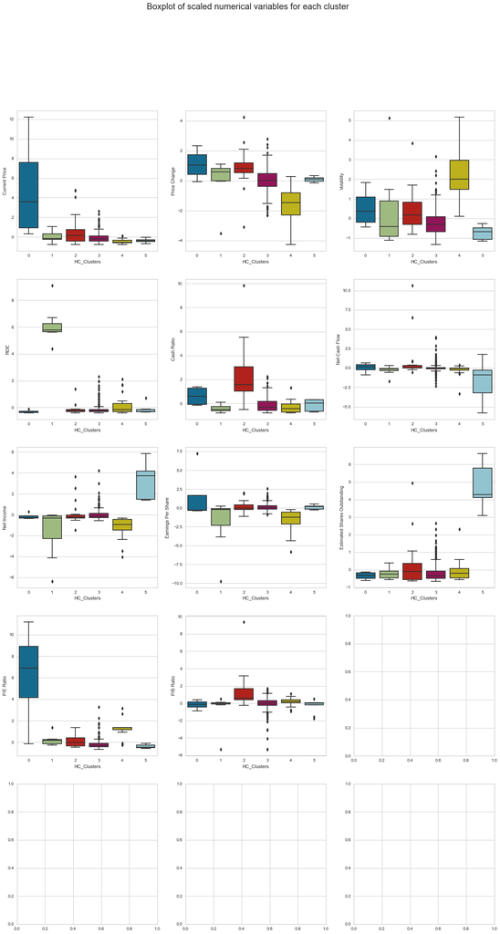

```python
fig, axes = plt.subplots(5, 3, figsize=(20, 35))
fig.suptitle("Boxplot of scaled numerical variables for each cluster", fontsize=20)
counter = 0
for ii in range(5):
    sns.boxplot(
        ax=axes[ii][0],
        y=subset_scaled_dfdata[num_cols[counter]],
        x=subset_scaled_dfdata["HC_Clusters"],
    )
    counter = counter + 1
    sns.boxplot(
        ax=axes[ii][1],
        y=subset_scaled_dfdata[num_cols[counter]],
        x=subset_scaled_dfdata["HC_Clusters"],
    )
    counter = counter + 1
    sns.boxplot(
        ax=axes[ii][2],
        y=subset_scaled_dfdata[num_cols[counter]],
        x=subset_scaled_dfdata["HC_Clusters"],
    )
    counter = counter + 1


fig.tight_layout(pad=3.0)
```

[output not shown]

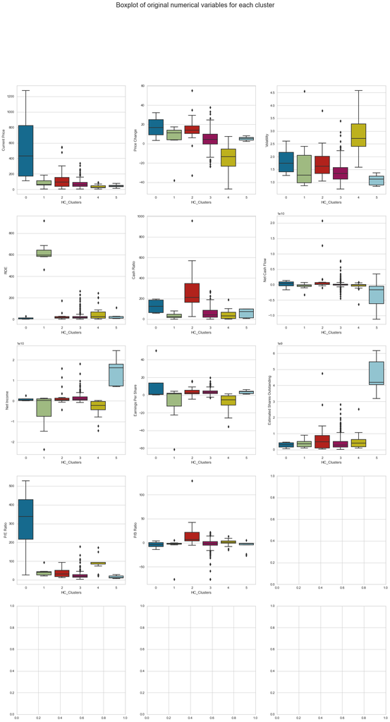

```python
fig, axes = plt.subplots(5, 3, figsize=(20, 35))
fig.suptitle("Boxplot of original numerical variables for each cluster", fontsize=20)
counter = 0
for ii in range(5):
    sns.boxplot(ax=axes[ii][0], y=dfdata[num_cols[counter]], x=dfdata["HC_Clusters"])
    counter = counter + 1
    sns.boxplot(ax=axes[ii][1], y=dfdata[num_cols[counter]], x=dfdata["HC_Clusters"])
    counter = counter + 1
    sns.boxplot(ax=axes[ii][2], y=dfdata[num_cols[counter]], x=dfdata["HC_Clusters"])
    counter = counter + 1


fig.tight_layout(pad=3.0)
```

## Insights

Clusters 0 (Blue):

- Current price midrange is ~$190 to $810. It is the portfolio for the priciest stocks.
- Price change is positive ranging from ~$3% to 32%.
- Volatility is moderate with a midrange between 1.4 and 2.2
- ROE is the lowest of all clusters.
- Cash ratio is all positive with a range of ~70 to 200%.

Cluster 1 (Green):

- Current price range is a little over $0 to just under $200.
- Price change is consistently positive.
- Volatility of the cluster includes the majority of the securities being below 1.5.
- ROE is the highest of all clusters with all securities returning over 400%.
- Cash ratio on average is lower than all other clusters.

Cluster 2 (Red ):

- Current price contains a porfolio of the second priciest stocks.
- Price change is strong with a majority of the underlying securities of the cluster exhibiting double digit returns.
- Volatility is moderate with an approximate range of 1 to 2.5.
- ROE is low and very similar to clusters 4 and 5.
- Cash ratio is strongest for this portfolio with almost 75% of the stocks having cash ratios than the stocks of other portfolios.

Cluster 3 (Violet):

- Current price contains several outliers driving averages higher. It is the portfolio with the third cheapest stocks.
- Price change is a normal distribution with the second largest range with 25% of securities having negative returns.
- Volatility for this cluster includes several outliers and contains the second lowest values of all the clusters.
- ROE of this portfolio contains a significant amount of outliers with most securities being relatively close to 0%.
- Cash ratio contains some outliers but is similar to clusters 4 and 5.

Cluster 4 (Yellow):

- Current price is the portfolio with securities with the lowest current prices.
- Price change is the worst performing portfolio with over 75% of securities having negative returns.
- Volatility for this cluster has the largest range going from a little over 1.5 to above 4.5.
- ROE is low and very similar to clusters 2 and 5.
- Cash ratio is similar to clusters 3 and 5.

Cluster 5 (Light Blue):

- Current price is the second lowest portfolio of securities.
- Price change is the narrowest of ranges provides a return of approximately 2-10%.
- Volatility is the narrowest of ranges and includes all securities being relatively involatile with all securities being belwo 1.5.
- ROE is low and very similar to clusters 2 and 4.
- Cash ratio is similar to clusters 3 and 4.

# Recommendation

Trade&Ahead should decide between K-Means Cluster 0 and Hierarchal Cluster 2. These two clusters are properly sized to hedge against risks while small enough to prevent the law of diminishing returns to prevent substantial returns. An ideal portfolio size needed to acheive this is 20-25 securites which both of these clusters achieve at 24 and 23 securities, respectively.

With the current economy preparing for rising interest rates, cash on hand statistics such as Cash Ratio, Net Cash Flow, and Net Income should be considered along with Price Change, Volatility and P/E ratio in determining which portfolio to select.